# Cell type assignment to methylation-based components - cellAssign

Reka Toth

30 June, 2022

```r
library(cellAssign)
library(ggplot2)
library(dplyr)
library(ggrepel)
library(annotatr)
library(tibble)
library(cowplot)
library(fgsea)
source("helper_functions.R")
```

# Prepare the datasets

## Promoter methylation

First, we need to load in a methylation dataset. It can be both array- and sequencing-based. Here we are using a mouse sequencing-based dataset, which was processed using the `methrix` package.

First, we identify the promoters in the genome and calculate the mean methylation value for all samples. The same can be achieved by using for example the command from the `RnBeads` package. Here I show an example processing, the processed files are provided in the data folder.

```r
res <- readRDS( "../data/no_snps_methrix.RDS") # a methrix object, not provided

promoters <- build_annotations("mm10", "mm10_genes_promoters")


promoter_methylation <- methrix::get_region_summary(res, promoters)
promoter_methylation$symbol <- promoters$symbol[promoter_methylation$rid]
promoter_methylation <- as.data.frame(promoter_methylation)

# filtersing for promoters overlapping with more than 1 CpG site and measured in most of the samples
promoter_methylation <- promoter_methylation %>%
   filter(n_overlap_CpGs>1) %>%
   filter(apply(., 1, function(x) sum(is.na(x)))<10)

# a data frame or a data table containing summarized methylation values for all promoters and all samples. Not provided.
saveRDS(promoter_methylation, file="../data/promoter_methylation.RDS")
```

Then, the promoter methylation data is correlated with the methylation components. In this case, the methylation components, named as LMCs, were calculated with [`MeDeCom`](https://github.com/lutsik/MeDeCom). The method of deconvolution is described in this [paper](https://www.nature.com/articles/s41596-020-0369-6).

```r
promoter_methylation <- readRDS( file="../data/promoter_methylation.RDS")

medecom.result <-  readRDS( file = "../data/poised_enhancers_new_samples.RDS") #results from the MeDeCom analysis

# assessing the LMC proportions, using K and lamda values based on the optimization. For further details, see the above cited paper
K_sel <- 4
lambda_sel <- 0.0001
proportions <- MeDeCom::getProportions(medecom.result, K=K_sel, lambda=lambda_sel)
colnames(proportions) <-  colnames(res)

#calculating the correlation
promoter_methylation <- promoter_methylation %>%
  "[<-"(paste0("LMC", 1:4), value = NA_real_) %>%
   "[<-"(paste0("LMC", 1:4, "_p"), value = NA_real_)

for (LMCs in paste0("LMC", 1:4)){

est <-lapply(1:nrow(promoter_methylation), function(x)
  cor.test(proportions[LMCs,],  as.numeric(promoter_methylation[x,-c(1:5, which(colnames(promoter_methylation)=="symbol"), grep("LMC", colnames(promoter_methylation)))]), method = "pears"))
promoter_methylation[,LMCs] <- unlist(lapply(est, function(x) x$estimate))
promoter_methylation[,paste0(LMCs, "_p")] <- -log10(unlist(lapply(est, function(x) x$p.value)))

}

df <- df %>%
   select(starts_with("LMC") | starts_with("symbol")) %>%
    filter(!is.na(symbol))
saveRDS(df, file="../data/control_correlation_LMCs.RDS") # data provided the the data folder.
```

Single-cell markers were downloaded from the [CellMarker database](http://bio-bigdata.hrbmu.edu.cn/CellMarker/download/Single_cell_markers.txt). In this case our samples are coming from mouse lung tissue, therefore we will use markers for those cell types.

```r
Single_cell_markers <- read.delim2("../data/Single_cell_markers.txt")
Single_cell_markers <- Single_cell_markers %>%
  filter(speciesType=="Mouse" & tissueType=="Lung" & cancerType=="Normal")
marker_list <- lapply(Single_cell_markers$geneSymbol, strsplit, split=", ")
marker_list <- lapply(marker_list, unlist)
names(marker_list) <- Single_cell_markers$cellName
```

For each LMC we can calculate enrichment scores using `fgsea`, using the correlation coefficients as ranks and the markers as gene sets. In a simplistic approach, promoter methylation is inversely correlated with gene expression, the LMC are assigned to those cell types with significant negative enrichment. The results are visualized with plots based on the `gseaplot` function of the `enrichplot` package. The helper_functions.R script contains the modified version of this plot used below.

```r
df <- readRDS(file="../data/control_correlation_LMCs.RDS")

LMC1_rank <-  df %>%
  arrange(desc(abs(LMC1)),desc(LMC1_p)) %>%
  mutate(symbol=replace(symbol, duplicated(symbol), NA))%>%
  dplyr::filter(!is.na(symbol)) %>%
  arrange(LMC1) %>%
  select(c( symbol, LMC1)) %>%
  tibble::deframe()


fgseaRes <- fgsea(pathways = marker_list,
                  stats    = LMC1_rank,
                  minSize  = 3,
                  maxSize  = 500, nperm=1000)
```

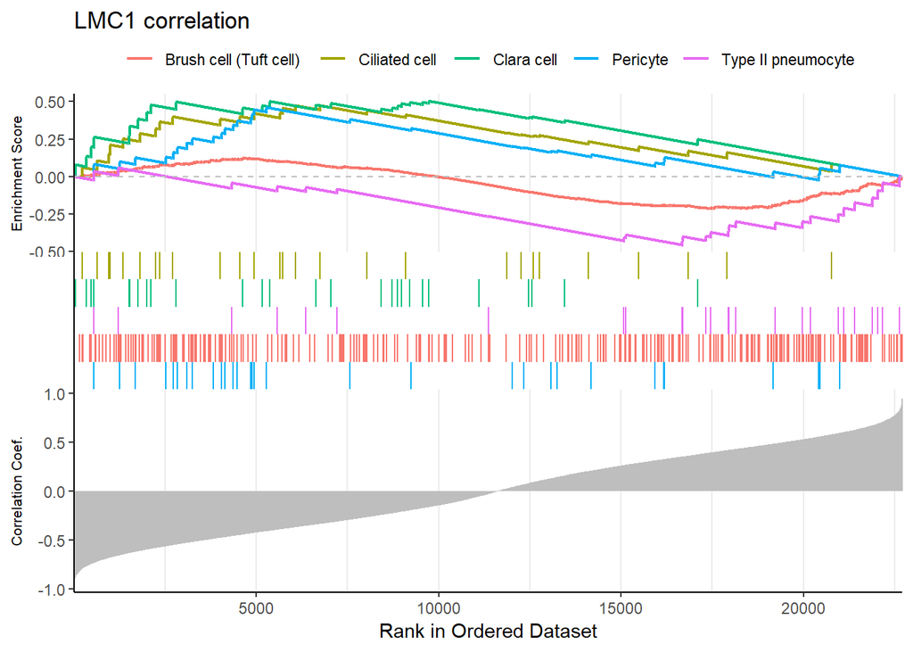

```r
LMC1_plot <- gseaplot2(geneSetID = c(which(fgseaRes$padj<0.05)),  base_size = 11, rel_heights = c(1.5, 0.8), subplots = c(1, 2, 3),  pvalue_table = FALSE, ES_geom = "line",
          title = "LMC1 correlation", ranks = LMC1_rank, geneSet = marker_list, pvaluetable = fgseaRes)
LMC1_plot
```

```r
LMC2_rank <-  df %>%
  arrange(desc(abs(LMC2)),desc(LMC2_p)) %>%
  mutate(symbol=replace(symbol, duplicated(symbol), NA))%>%
  dplyr::filter(!is.na(symbol)) %>%
  arrange(LMC2) %>%
  select(c( symbol, LMC2)) %>%
  tibble::deframe()


fgseaRes <- fgsea(pathways = marker_list,
                  stats    = LMC2_rank,
                  minSize  = 3,
                  maxSize  = 500, nperm=1000)
```

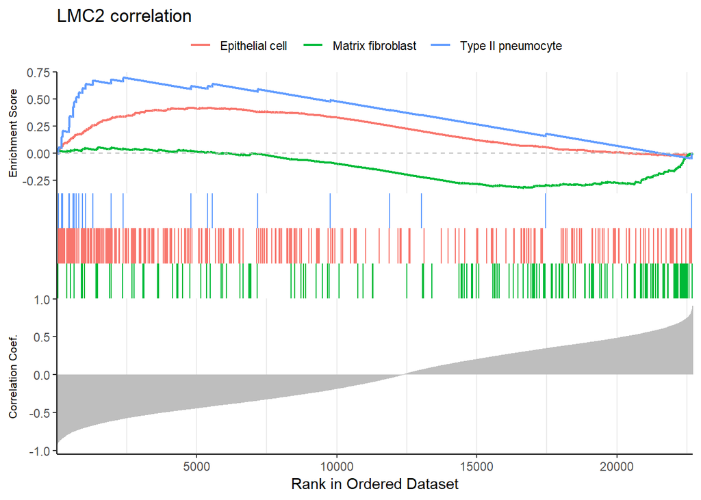

```r
LMC2_plot <- gseaplot2(geneSetID = c(which(fgseaRes$padj<0.05)),  base_size = 11, rel_heights = c(1.5, 0.8), subplots = c(1, 2, 3),  pvalue_table = FALSE, ES_geom = "line",
          title = "LMC2 correlation", ranks = LMC2_rank, geneSet = marker_list, pvaluetable = fgseaRes)
LMC2_plot
```